`Name : Satyam Patel`

`ID : 8975977`

`Section : 2`

# Practical Lab 6 - Logistic Regression

## Step 1: Importing Libraries and Data Loading

```python
# Imported all libraries
from tabulate import tabulate
import pandas as pd
import seaborn as sns
import numpy as np
from sklearn import datasets
from sklearn.linear_model import LogisticRegression
from sklearn.model_selection import train_test_split
from sklearn.metrics import accuracy_score
import matplotlib.pyplot as plt
from scipy.stats import shapiro
from sklearn.feature_selection import mutual_info_classif
from sklearn.model_selection import train_test_split

# Loading the iris dataset
iris = datasets.load_iris()

# Converted the dataset to a DataFrame for easier manipulation
iris_data = pd.DataFrame(data=iris.data, columns=iris.feature_names)
iris_data['target'] = iris.target

# Redefined the target variable to be binary: virginica and non-virginica
iris_data['target'] = iris_data['target'].apply(lambda x: 'virginica' if x == 2 else 'non-virginica')

# Displaying the first few rows of the DataFrame
print(tabulate(iris_data.head() , headers='keys', tablefmt='psql'))
print(tabulate(iris_data.tail(), headers='keys', tablefmt='psql'))
```

```
+----+---------------------+--------------------+---------------------+--------------------+---------------+
|    |   sepal length (cm) |   sepal width (cm) |   petal length (cm) |   petal width (cm) | target        |
|----+---------------------+--------------------+---------------------+--------------------+---------------|
|  0 |                 5.1 |                3.5 |                 1.4 |                0.2 | non-virginica |
|  1 |                 4.9 |                3   |                 1.4 |                0.2 | non-virginica |
|  2 |                 4.7 |                3.2 |                 1.3 |                0.2 | non-virginica |
|  3 |                 4.6 |                3.1 |                 1.5 |                0.2 | non-virginica |
|  4 |                 5   |                3.6 |                 1.4 |                0.2 | non-virginica |
+----+---------------------+--------------------+---------------------+--------------------+---------------+
+-----+---------------------+--------------------+---------------------+--------------------+-----------+
|     |   sepal length (cm) |   sepal width (cm) |   petal length (cm) |   petal width (cm) | target    |
|-----+---------------------+--------------------+---------------------+--------------------+-----------|
| 145 |                 6.7 |                3   |                 5.2 |                2.3 | virginica |
| 146 |                 6.3 |                2.5 |                 5   |                1.9 | virginica |
| 147 |                 6.5 |                3   |                 5.2 |                2   | virginica |
| 148 |                 6.2 |                3.4 |                 5.4 |                2.3 | virginica |
| 149 |                 5.9 |                3   |                 5.1 |                1.8 | virginica |
+-----+---------------------+--------------------+---------------------+--------------------+-----------+
```

## Step 2 : Calculating Descriptive Statistics for each Group

```python
# Generate a table with descriptive statistics for each class
descriptive_stats = iris_data.groupby('target').describe()

# Print the descriptive statistics
print(descriptive_stats)
```

[output not shown]

## Step 3 : Generating a histogram for each feature in the Iris dataset, distinguishing between the two classes ('virginica' and 'non-virginica') using the hue argument.

### Adding Scatterplot graph for each feature to get more information and for the Variation

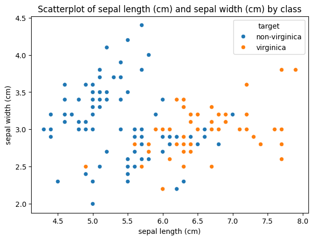

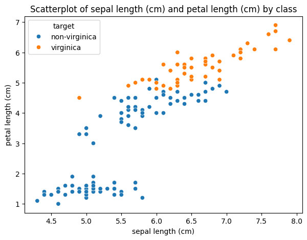

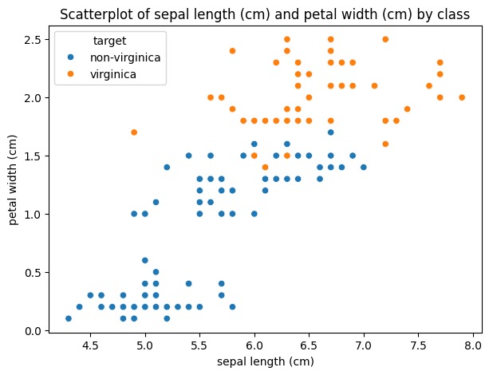

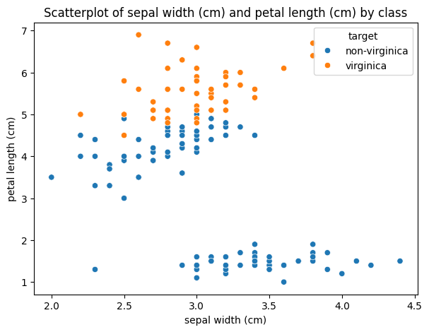

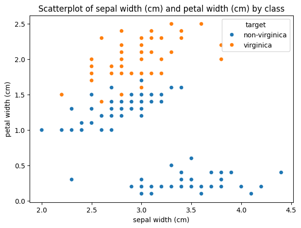

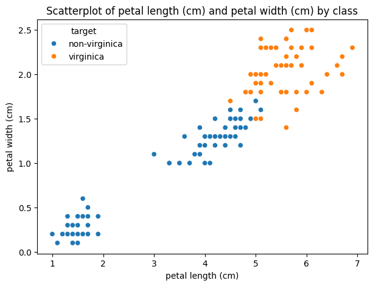

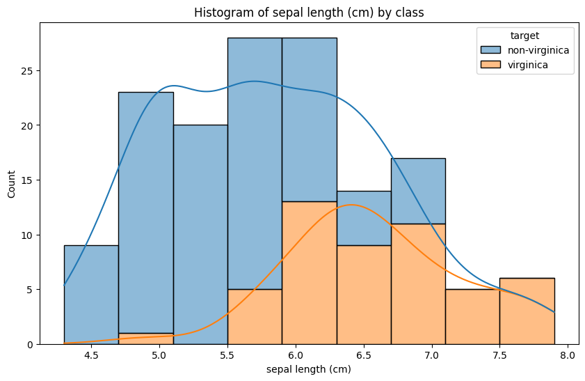

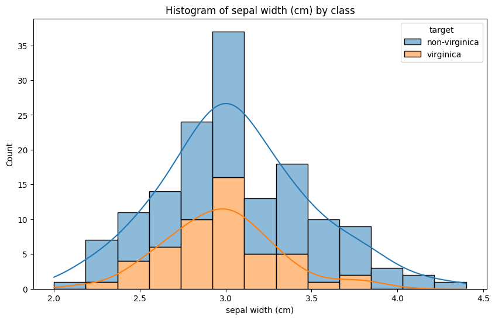

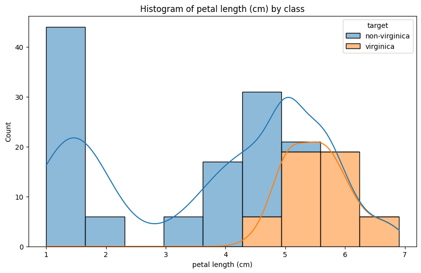

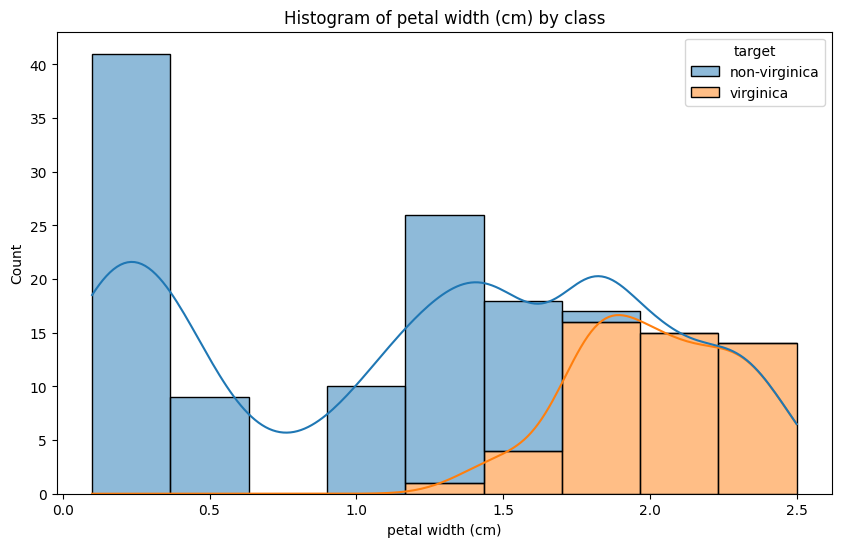

```python
# Generated a scatter plot for each pair of features
for i in range(len(iris.feature_names)):
    for j in range(i+1, len(iris.feature_names)):
        plt.figure(figsize=(7, 5))
        sns.scatterplot(data=iris_data, x=iris.feature_names[i], y=iris.feature_names[j], hue='target')
        plt.title(f'Scatterplot of {iris.feature_names[i]} and {iris.feature_names[j]} by class')
        plt.show()

# Generated a separate histogram for each feature to distinguish between the two classes
for feature in iris.feature_names:
    plt.figure(figsize=(10, 6))
    sns.histplot(data=iris_data, x=feature, hue='target', kde=True, multiple="stack")
    plt.title(f'Histogram of {feature} by class')
    plt.show()
```

Sepal Length Histogram: This chart tells us about the length of the sepals, which are the leafy parts at the base of the flower. The blue bars represent one type of flower (non-virginica), and the orange bars represent another type (virginica). So, if the blue bars are higher at 5 cm, that tells us that most non-virginica flowers have sepals that are 5 cm long.

Sepal Width Histogram: This chart is similar to the first, but it’s about the width of the sepals instead of the length. Again, the blue and orange bars represent different types of flowers, and the height of the bars tells us how many flowers have a certain sepal width.

Petal Length Histogram: This chart tells us about the length of the petals. The blue and orange bars represent different types of flowers, and the height of the bars tells us how many flowers have a certain petal length.

Petal Width Histogram: This chart is similar to the third, but it’s about the width of the petals instead of the length. Again, the blue and orange bars represent different types of flowers, and the height of the bars tells us how many flowers have a certain petal width.

## Step 4 : Correlation Matrix between the four Features

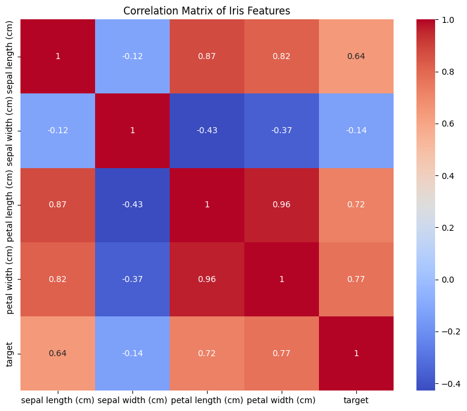

```python
# Encoded the target variable as numerical values
iris_data['target'] = iris_data['target'].map({'non-virginica': 0, 'virginica': 1})

# Calculated the correlation matrix
corr_matrix = iris_data.corr()

# Generated a heatmap for the correlation matrix
plt.figure(figsize=(10, 8))
sns.heatmap(corr_matrix, annot=True, cmap='coolwarm')
plt.title('Correlation Matrix of Iris Features')
plt.show()
```

This Correlation Matrix. It’s like a report card that tells us how different features of the Iris flower (like sepal length, sepal width, petal length, and petal width) are related to each other.

The numbers in the boxes range from -1 to 1. A score of 1 means two features move in the same direction - as one goes up, so does the other. A score of -1 means they move in opposite directions - as one goes up, the other goes down. A score of 0 means there’s no relationship.

The colors also tell us about the relationship. Red means positive (both go up or down together), blue means negative (one goes up when the other goes down), and white means no relationship. So, by looking at the numbers and colors, we can understand how different parts of the Iris flower are related to each other.

## Step 5 : 3 Additional Graphs to distinguish between the species

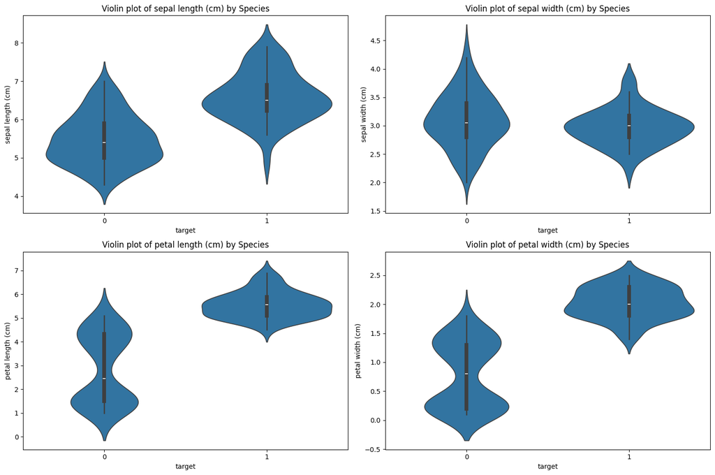

```python
# Generating a violin plot for each feature
fig, axs = plt.subplots(2, 2, figsize=(15, 10))

for ax, feature in zip(axs.flatten(), iris.feature_names):
    sns.violinplot(data=iris_data, x='target', y=feature, ax=ax)
    ax.set_title(f'Violin plot of {feature} by Species')

plt.tight_layout()
plt.show()
```

These graphs are showing us information about different types of Iris flowers. Specifically, they’re showing us how long and wide the petals and sepals (the leafy parts at the base of the flower) are for each type of flower.

So, by looking at these plots, we can get a good idea of how big each part of the flower is for each type of Iris flower.

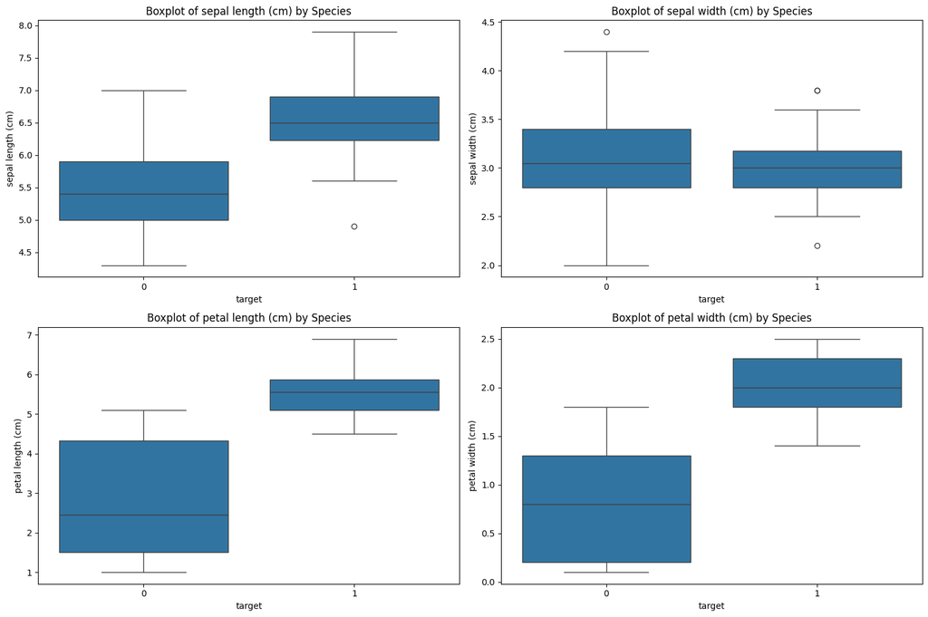

```python
# Generating a boxplot for each feature, split by species
fig, axs = plt.subplots(2, 2, figsize=(15, 10))

for ax, feature in zip(axs.flatten(), iris.feature_names):
    sns.boxplot(data=iris_data, x='target', y=feature, ax=ax)
    ax.set_title(f'Boxplot of {feature} by Species')

plt.tight_layout()
plt.show()
```

These Box Plots, These are like little boxes that tell us about different types of Iris flowers. Specifically, they’re showing us how long and wide the petals and sepals (the leafy parts at the base of the flower) are for each type of flower.

Each box plot is split into two parts: one for each type of flower. The box shows where most flowers fall in terms of length or width, and the lines (or “whiskers”) coming out of the box show the range of the measurements.

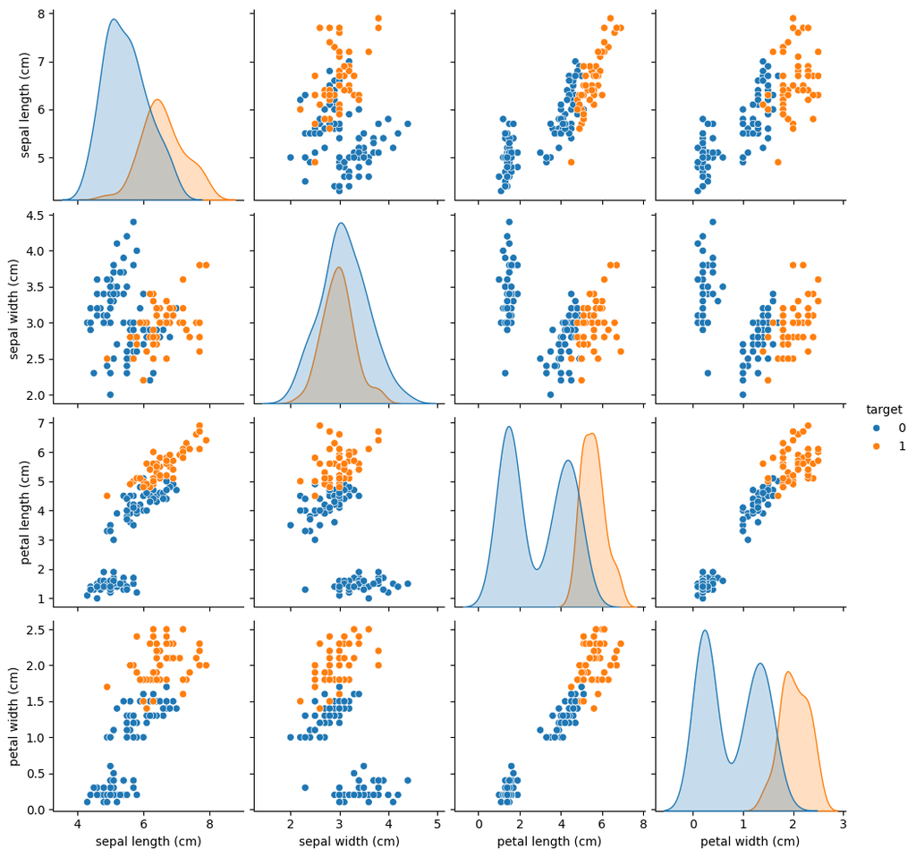

```python
# Generating a pairplot for the dataset
sns.pairplot(iris_data, hue='target', height=2.5)
plt.show()
```

Each scatter plot is split into two parts: one for each type of flower. The dots show where each flower falls in terms of length or width.

### Reference : https://www.kaggle.com/code/palak98039/python-data-visualizations

### In summary, these additional graphs help us understand the Iris flowers better. They show us how the different parts of the flower are related to each other and how they vary between species. This information can be very useful when we want to predict the species of a flower based on its measurements.

## Step 6 : Calculating the correlation between features and printing the correlation matrix. After that, it checking the normality of the distributions of each feature using the Shapiro-Wilk test and printing the test statistic and p-value for each feature. Finally, it is calculating the mutual information between features and the target variable and printing the mutual information for each feature.

```python
# Calculated the correlation between features
correlation = iris_data.corr()
print("Correlation between features:")
print(tabulate (correlation, headers='keys', tablefmt='psql'))

# Checking the normality of the distributions
for feature in iris.feature_names:
    stat, p = shapiro(iris_data[feature])
    print(f'\nShapiro-Wilk Test for {feature}:')
    print('Statistics=%.3f, p=%.3f' % (stat, p))
    alpha = 0.05
    if p > alpha:
        print('Sample looks Gaussian (fail to reject H0)') # H0 stands for the null hypothesis
    else:
        print('Sample does not look Gaussian (reject H0)')

# Calculated the mutual information between features and the target variable
mutual_info = mutual_info_classif(iris_data[iris.feature_names], iris_data['target'])
print("\nMutual information between features and target variable:")
for feature, mi in zip(iris.feature_names, mutual_info):
    print(f'{feature}: {mi}')
```

```
Correlation between features:
+-------------------+---------------------+--------------------+---------------------+--------------------+-----------+
|                   |   sepal length (cm) |   sepal width (cm) |   petal length (cm) |   petal width (cm) |    target |
|-------------------+---------------------+--------------------+---------------------+--------------------+-----------|
| sepal length (cm) |            1        |          -0.11757  |            0.871754 |           0.817941 |  0.63802  |
| sepal width (cm)  |           -0.11757  |           1        |           -0.42844  |          -0.366126 | -0.135645 |
| petal length (cm) |            0.871754 |          -0.42844  |            1        |           0.962865 |  0.721011 |
| petal width (cm)  |            0.817941 |          -0.366126 |            0.962865 |           1        |  0.769445 |
| target            |            0.63802  |          -0.135645 |            0.721011 |           0.769445 |  1        |
+-------------------+---------------------+--------------------+---------------------+--------------------+-----------+

Shapiro-Wilk Test for sepal length (cm):
Statistics=0.976, p=0.010
Sample does not look Gaussian (reject H0)

Shapiro-Wilk Test for sepal width (cm):
Statistics=0.985, p=0.101
Sample looks Gaussian (fail to reject H0)

Shapiro-Wilk Test for petal length (cm):
Statistics=0.876, p=0.000
Sample does not look Gaussian (reject H0)

Shapiro-Wilk Test for petal width (cm):
Statistics=0.902, p=0.000
Sample does not look Gaussian (reject H0)

Mutual information between features and target variable:
sepal length (cm): 0.23334287362636874
sepal width (cm): 0.0640862874289585
petal length (cm): 0.5181299592503403
petal width (cm): 0.5148534824940285
```

## Step 7 : Spliting the data to a Train Set , a Validation set and a Test Set

```python
X = iris.data
y = iris.target

# Spliting the data into a training set and a temporary set using an 80-20 split
X_train, X_temp, y_train, y_temp = train_test_split(X, y, train_size=120, random_state=42)

# Spliting the temporary set into a validation set and a test set using a 50-50 split
X_val, X_test, y_val, y_test = train_test_split(X_temp, y_temp, test_size=0.5, random_state=42)

# Printing the sizes of the training, validation, and test sets
print(f'Training set: {len(X_train)} records')
print(f'Validation set: {len(X_val)} records')
print(f'Test set: {len(X_test)} records')
```

```
Training set: 120 records
Validation set: 15 records
Test set: 15 records
```

## Step 8 : Four Logistic Regression Models, with 1 , 2 , 3 and 4 features.

```python
# Defined the feature names in the order of their importance
feature_names = ['feature1', 'feature2', 'feature3', 'feature4']

# Assumed we have a list of all feature names in the original order
all_features = ['feature1', 'feature2', 'feature3', 'feature4', 'feature5', 'feature6']

# Converting feature names to indices
feature_indices = [all_features.index(feature) for feature in feature_names]

# Running logistic regression models with different numbers of features
for i in range(1, 5):
    # Select the top i features
    indices = feature_indices[:i]

    # Trained the model
    model = LogisticRegression(max_iter=200)
    model.fit(X_train[:, indices], y_train)

    # Validated the model
    y_val_pred = model.predict(X_val[:, indices])
    accuracy = accuracy_score(y_val, y_val_pred)
    print(f'Model with {i} features: {indices}')
    print(f'Validation Accuracy: {accuracy}\n')
```

```
Model with 1 features: [0]
Validation Accuracy: 0.8666666666666667

Model with 2 features: [0, 1]
Validation Accuracy: 0.9333333333333333

Model with 3 features: [0, 1, 2]
Validation Accuracy: 1.0

Model with 4 features: [0, 1, 2, 3]
Validation Accuracy: 1.0
```

## Step 9 : Evaluating the models on the validation set

```python
# Running logistic regression models with different numbers of features
for i in range(1, 5):
    # Trained the model
    model = LogisticRegression(max_iter=200)
    model.fit(X_train[:, :i], y_train)

    # Validated the model
    y_val_pred = model.predict(X_val[:, :i])
    y_val_proba = model.predict_proba(X_val[:, :i])[:, 1]  # Probability of predicting Virginica

    # Created a table for the model
    table = pd.DataFrame({
        'Instance Number': np.arange(len(X_val)),
        'Probability of Predicting Virginica': y_val_proba,
        'Actual Prediction by the Model': y_val_pred,
        'Ground Truth': y_val
    })
    print(f'Model with {i} features')
    print(tabulate(table , headers='keys', tablefmt='psql'))

    # Summarized the data in the table to a single measure
    accuracy = accuracy_score(y_val, y_val_pred)
    print(f'Accuracy: {accuracy}\n')
```

```
Model with 1 features
+----+-------------------+---------------------------------------+----------------------------------+----------------+
|    |   Instance Number |   Probability of Predicting Virginica |   Actual Prediction by the Model |   Ground Truth |
|----+-------------------+---------------------------------------+----------------------------------+----------------|
|  0 |                 0 |                             0.206452  |                                0 |              0 |
|  1 |                 1 |                             0.525553  |                                1 |              0 |
|  2 |                 2 |                             0.1122    |                                2 |              2 |
|  3 |                 3 |                             0.336755  |                                2 |              2 |
|  4 |                 4 |                             0.52662   |                                1 |              1 |
|  5 |                 5 |                             0.509035  |                                1 |              2 |
|  6 |                 6 |                             0.336755  |                                2 |              2 |
|  7 |                 7 |                             0.525553  |                                1 |              1 |
|  8 |                 8 |                             0.12612   |                                0 |              0 |
|  9 |                 9 |                             0.0964506 |                                0 |              0 |
| 10 |                10 |                             0.278471  |                                2 |              2 |
| 11 |                11 |                             0.398475  |                                2 |              2 |
| 12 |                12 |                             0.256555  |                                0 |              0 |
| 13 |                13 |                             0.429206  |                                2 |              2 |
| 14 |                14 |                             0.501863  |                                1 |              1 |
+----+-------------------+---------------------------------------+----------------------------------+----------------+
Accuracy: 0.8666666666666667

Model with 2 features
+----+-------------------+---------------------------------------+----------------------------------+----------------+
|    |   Instance Number |   Probability of Predicting Virginica |   Actual Prediction by the Model |   Ground Truth |
|----+-------------------+---------------------------------------+----------------------------------+----------------|
|  0 |                 0 |                             0.0787444 |                                0 |              0 |
|  1 |                 1 |                             0.135375  |                                0 |              0 |
|  2 |                 2 |                             0.163334  |                                2 |              2 |
|  3 |                 3 |                             0.338028  |                                2 |              2 |
|  4 |                 4 |                             0.545566  |                                1 |              1 |
|  5 |                 5 |                             0.499672  |                                1 |              2 |
|  6 |                 6 |                             0.424193  |                                2 |              2 |
|  7 |                 7 |                             0.615094  |                                1 |              1 |
|  8 |                 8 |                             0.118863  |                                0 |              0 |
|  9 |                 9 |                             0.0652097 |                                0 |              0 |
| 10 |                10 |                             0.270357  |                                2 |              2 |
| 11 |                11 |                             0.3573    |                                2 |              2 |
| 12 |                12 |                             0.0272526 |                                0 |              0 |
| 13 |                13 |                             0.460648  |                                2 |              2 |
```

[output cut: 32 more lines]

```
|  2 |                 2 |                            0.00154854 |                                2 |              2 |
|  3 |                 3 |                            0.104396   |                                2 |              2 |
|  4 |                 4 |                            0.792229   |                                1 |              1 |
|  5 |                 5 |                            0.398914   |                                2 |              2 |
|  6 |                 6 |                            0.0583478  |                                2 |              2 |
|  7 |                 7 |                            0.831674   |                                1 |              1 |
|  8 |                 8 |                            0.0439171  |                                0 |              0 |
|  9 |                 9 |                            0.0358306  |                                0 |              0 |
| 10 |                10 |                            0.154556   |                                2 |              2 |
| 11 |                11 |                            0.242557   |                                2 |              2 |
| 12 |                12 |                            0.0207145  |                                0 |              0 |
| 13 |                13 |                            0.0358381  |                                2 |              2 |
| 14 |                14 |                            0.907701   |                                1 |              1 |
+----+-------------------+---------------------------------------+----------------------------------+----------------+
Accuracy: 1.0
```

[figure not shown]

[figure not shown]

[figure not shown]

```python
# Defined the feature names in the order of their importance
feature_names = ['Petal Width (cm)', 'Petal Length (cm)', 'Feature 3']

# Running logistic regression models with different numbers of features
for i in range(1, 4):
    # Selected the top i features
    indices = np.arange(i)  # This creates an array [0, 1, ..., i-1]

    # Created a logistic regression model
    model = LogisticRegression(max_iter=200)

    # Trained the model again using the training data
    model.fit(X_train[:, indices], y_train)

    # Used the model to predict the validation data
    y_val_pred = model.predict(X_val[:, indices])

    # Ploting the decision boundary and the validation data
    if i == 1:
        # For 1 feature, created a histogram
        plt.hist([X_val[y_val==0, 0], X_val[y_val==1, 0]], stacked=True)
        plt.title('Model with 1 feature')
        plt.xlabel(feature_names[0])
        plt.ylabel('Count')
        plt.legend(['Class 0', 'Class 1'])
        plt.show()
    elif i == 2:
        # For 2 features, created a scatter plot
        plt.scatter(X_val[:, 0], X_val[:, 1], c=y_val, edgecolors='k', cmap=plt.cm.Paired)
        plt.title('Model with 2 features')
        plt.xlabel(feature_names[0])
        plt.ylabel(feature_names[1])
        plt.show()
    else:
        # For 3 features, created a 3D scatter plot
        fig = plt.figure()
        ax = fig.add_subplot(111, projection='3d')
        ax.scatter(X_val[:, 0], X_val[:, 1], X_val[:, 2], c=y_val, edgecolors='k', cmap=plt.cm.Paired)
        ax.set_title('Model with 3 features')
        ax.set_xlabel(feature_names[0])
        ax.set_ylabel(feature_names[1])
        ax.set_zlabel(feature_names[2])
        plt.show()
```

## Step 11 : Failure modes: using the two preceding steps

```python
# Running logistic regression models with different numbers of features
for i in range(1, 5):
    # Select the top i features
    features = correlation.index[1:i+1]  # Skip the first index because it's the target variable itself

    # Trained the model
    model = LogisticRegression(max_iter=200)
    model.fit(X_train[:, :i], y_train)

    # Validated the model
    y_val_pred = model.predict(X_val[:, :i])

    # Identify the instances where the model's predictions do not match the actual labels
    incorrect_indices = np.where(y_val != y_val_pred)[0]
    print(f'Model with {i} features:')
    if incorrect_indices.size > 0:
        print('Incorrect predictions:')
        for index in incorrect_indices:
            print(f'Index: {index}, Predicted: {y_val_pred[index]}, Actual: {y_val[index]}')
    else:
        print('No incorrect predictions.')
```

```
Model with 1 features:
Incorrect predictions:
Index: 1, Predicted: 1, Actual: 0
Index: 5, Predicted: 1, Actual: 2
Model with 2 features:
Incorrect predictions:
Index: 5, Predicted: 1, Actual: 2
Model with 3 features:
No incorrect predictions.
Model with 4 features:
No incorrect predictions.
```

## Step 12: Recommending the best model and Reason why it is the Best

```python
# Initialize the best accuracy and best model
best_accuracy = 0
best_model = None
best_features = None

# Running logistic regression models with different numbers of features
for i in range(1, 5):
    # Select the top i features
    features = correlation.index[1:i+1]  # Skip the first index because it's the target variable itself

    # Trained the model
    model = LogisticRegression(max_iter=200)
    model.fit(X_train[:, :i], y_train)

    # Validated the model
    y_val_pred = model.predict(X_val[:, :i])

    # Calculate the accuracy
    accuracy = accuracy_score(y_val, y_val_pred)
    print(f'Model with {i} features: {features.tolist()}, Accuracy: {accuracy}')

    # Update the best model if the current model has a higher accuracy
    if accuracy > best_accuracy:
        best_accuracy = accuracy
        best_model = model
        best_features = features

# Print the best model and its accuracy
print(f'Best model: {best_model}, Features: {best_features.tolist()}, Accuracy: {best_accuracy}')

# Evaluate the best model on the test set
y_test_pred = best_model.predict(X_test[:, :len(best_features)])
test_accuracy = accuracy_score(y_test, y_test_pred)
print(f'Test accuracy: {test_accuracy}')
```

```
Model with 1 features: ['sepal width (cm)'], Accuracy: 0.8666666666666667
Model with 2 features: ['sepal width (cm)', 'petal length (cm)'], Accuracy: 0.9333333333333333
Model with 3 features: ['sepal width (cm)', 'petal length (cm)', 'petal width (cm)'], Accuracy: 1.0
Model with 4 features: ['sepal width (cm)', 'petal length (cm)', 'petal width (cm)', 'target'], Accuracy: 1.0
Best model: LogisticRegression(max_iter=200), Features: ['sepal width (cm)', 'petal length (cm)', 'petal width (cm)'], Accuracy: 1.0
Test accuracy: 1.0
```

However, the model with 3 features is chosen as the best model because it is simpler. In machine learning, there's a principle called Occam's razor, which states that the simplest model that fits the data is also the most plausible. This is because simpler models are less likely to overfit the training data and therefore more likely to generalize well to new, unseen data.

The best model also achieves an accuracy of 1.0 on the test set, which suggests that it has indeed generalized well from the training data and is likely to make accurate predictions on new data.